# Lab 2: Population Growth Experiment

By The BI271 Team

2018 October 2–4

# 1 Learning outcomes

1. Conduct a controlled experiment to observe single-species population growth
2. Translate experimental data to ecologically-meaningful parameters
3. Assess experimental treatment
4. In addition to building on how to write methods and results sections, how to structure and write an introduction section

# 2 Background

## 2.1 Origins

“. . . the power of population is indefinitely greater than the power in the earth to produce subsistence for man. Population, when unchecked, increases in a geometrical ratio. Subsistence increases only in an arithmetical ratio. A slight acquaintance with numbers will show the immensity of the first power in comparison of the second.” —Thomas Malthus, 1795, *An Essay on the Principle of Population*

“The growth of the population necessarily has a limit, if only in the extent of the land indispensable for the housing of that population. . . . All the formulas by which one may attempt to represent the law of populations must therefore satisfy the condition of allowing for a maximum which will only be reached in an extremely remote era. This maximum will be the total of the population which tends to become stationary.” —Pierre Verhulst, 1838, *Notice sur la loi que la population suit dans son accroissement* (English: *Notice on the law that the population follows in its growth*)

How populations change has been a focal inquiry of scientists over the past few centuries. Its modern intellectual origins are most prominently rooted in the Age of Enlightenment and Industrial Revolution. Scientists, economists, demographers, and others began to contemplate ever-increasing densities in Europe’s largest cities in addition to the consequences of increased lifespan afforded by the increase of the standard of living during Industrial Revolution.

From the mid-19<sup>th</sup> to the early 20<sup>th</sup> century, verbal and mathematical models describing how populations change would be independently discovered **five** times in different parts of the world—illustrating what an important concept population growth had become. In the 1920s the mathematical equation describing population growth had spread widely, including to the new field of ecology. There were slightly different equations to describe how populations changed, but they all had the same qualitative properties/behaviors. These are:

1. When populations are small, they grow (*sensu* Malthus)
2. There is a maximum population size that populations will grow towards, whether they are above or below that value (*sensu* Verhulst)

The previous century had seen almost a doubling in population size of the global human population. The repercussions of such growth are quickly realized when you begin with, say, a global population of around 1.5 billion people in 1900. If doubling occurred every century, in just a few centuries, it seems possible that humans would have out growth Earth! Similarly, Malthus, in *An Essay on the Principle of Population*, reasoned that the European populations in the United States were doubling every 25 years, and from then (1795) to the end of its first century, the population would grow from ~7 to 112 million people! That was an unprecedented number of people at that time, and, with history at our fingertips, we now know Malthus was off by about 1/2, as the United States population was ~62 million (including indigenous Americans). Nevertheless, Malthus’s observation about the propensity of populations to reproduce when small or not limited by space or food was a key step towards understanding the power of populations to grow.

Pierre Verhulst built upon Malthus’ work when he formulated what he named *the logistic curve*. Synonymous with logistic equation, logistic model, and logistic function, Verhulst added a second term to the mathematical representation of population growth. The term took into account the effect of crowding or, in his words, “the retarding force” that slows population growth as they increase and resources per individual become increasingly diminished.

We discuss the models in the next section, after we look at some observations.

## 2.2 Observations

The earliest data on population growth was human populations from European countries and the United States. Pearl and Reed (1920, *On the rate of growth of the population of the United States since 1790 and its mathematical representation*, Pro. Nat. Ac. Sci.) presented United States data in a widely circulated article:

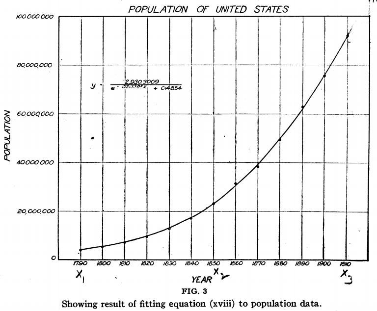

These data clearly show growth, but there doesn’t seem to be much of an effect of crowding. Pearl and Reed nevertheless estimate the parameters of the logistic model they present, and estimate that the maximum population size for the United States will be 197,274,000. Their most recent data point was from 1910 and the Unites States population was just over 91,000,000; now, the population of the United States is currently just over 325,000,000.

Soon after, data on populations experimental systems were presented. Here are two figures from Lotka’s 1926 book, *Elements of physical biology*:

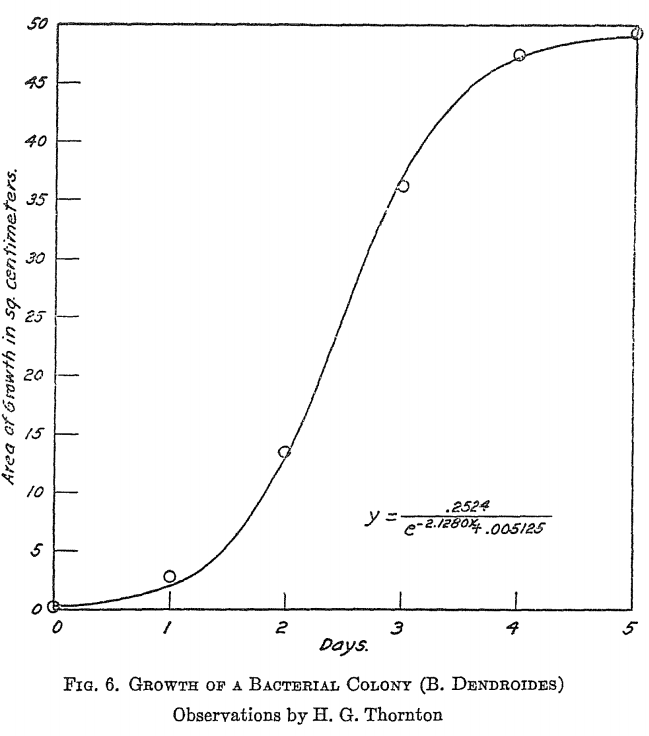

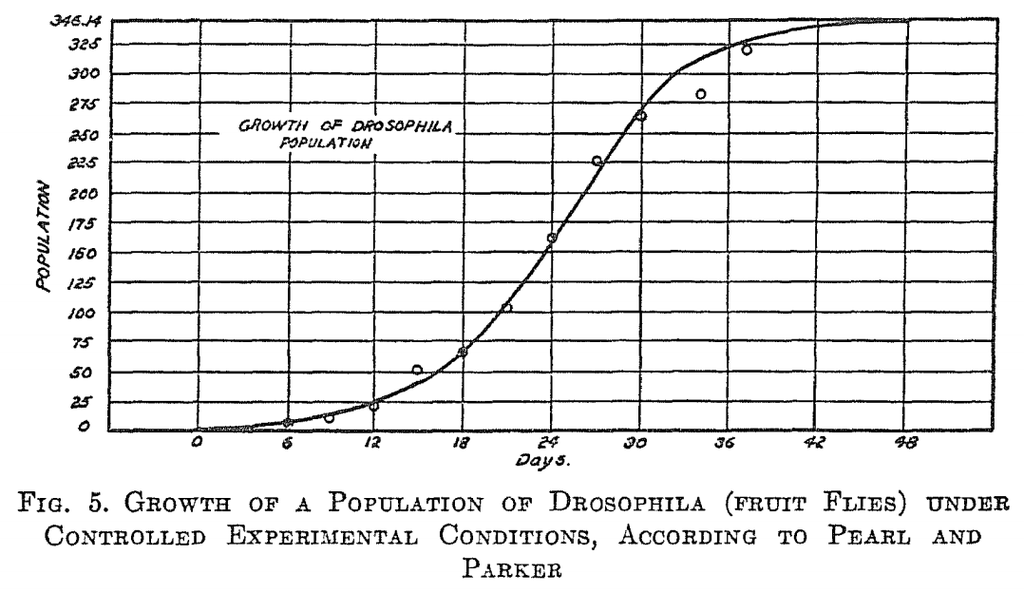

Showing population growth for bacterial and fruit fly colonies in the respective left and right figures. Here, the growth of the populations, unlike humans at that point, seems to increase when at lower abundance, then grow up to a point. Below are figures from Gause’s 1934 book, *The struggle for existence*:

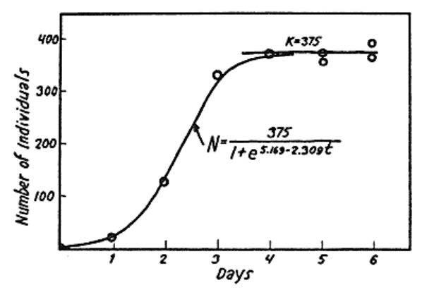

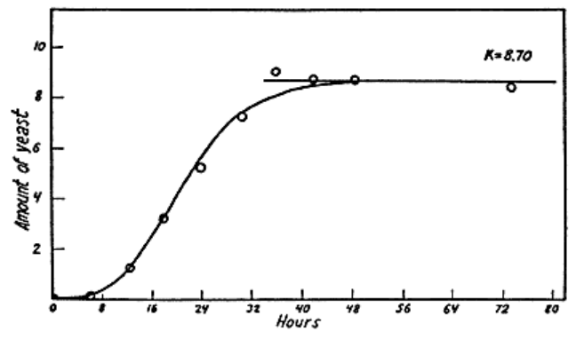

The left and right figures respectively show population growth of *Paramecium* and yeast.

As it turns out, in highly controlled laboratories, populations of organisms with simple life histories (e.g., those that reproduce asexually, those that are unicellular) almost invariably grow in the manner that you see in this section. This is commonly called “logistic growth” after the logistic model, but also “sigmoidal growth” because the curve is roughly “S” shaped and *sigma* is “S” from Greek.

For populations that are in less controlled settings or have complex life histories, their growth curves don’t necessarily follow the same pattern. For example, here are data from the larch budmoth (*Zeiraphera diniana*) in Switzerland (Turchin et al., 2003, *Dynamical effects of plant quality and parasitism on population cycles of larch budmoth*):

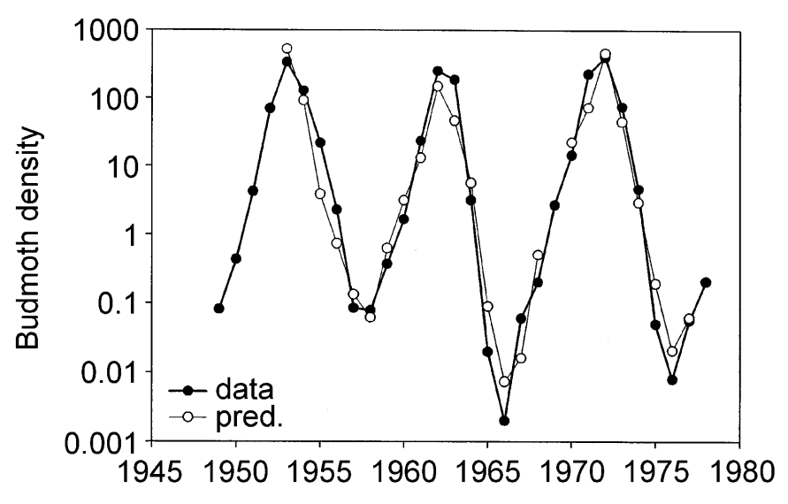

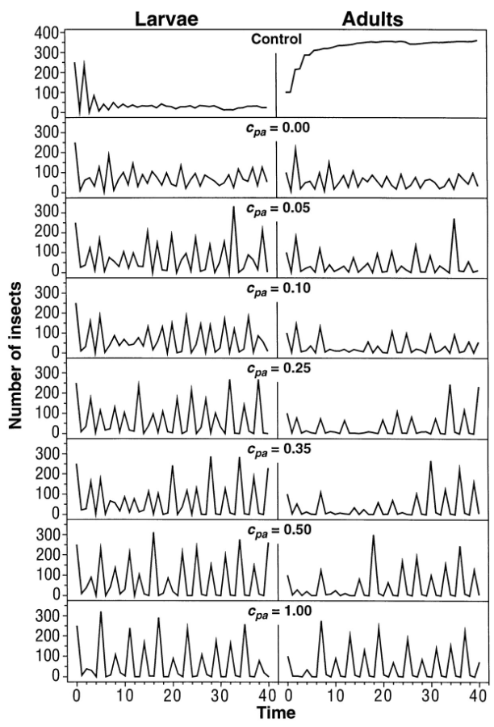

Here, the populations change chaotically in the technical, but also in the colloquial senses.

The logistic model isn’t perfect, but neither is any model that one could make for the multifariousness of life on Earth. Nevertheless, it remains relevant in ecology because it can be useful in many instances. Below, we showcase the logistic model.

## 2.3 Models

To begin, consider some of the figures from above: the bacterial culture, the *Paramecium*, fruit fly, and yeast growth. These figures depict the relationship between time and abundance. Here, time is the independent variable and abundance is dependent variable, traditionally depicted on the horizontal and vertical axes, respectively. We call plots with time as a variable a “time series.” We ideally would want to write a model with the dependent variable, say $y$ as a function of the independent variable $x$, generally:
$$y = f(x)$$
or specifically for our case, with $t$ as time and $N$ as population abundance:
$$N = f(t)\text{.}$$
We could use any sigmoidal function as $f(\cdot)$ ($f(\cdot)$ means $g$ is a function of some variable), and it will be able to accurately model the observed data, but we’d ideally want to use an expression that has biologically-meaningful parameters.

### 2.3.1 The differential equation

As it turns out, the most elegant and useful way of writing $N = f(t)$ is by expressing it in terms of its derivative, allowing us to harness the power of calculus. This means, we wish to write down a function that expresses the rate of change of a population over time, or
$$\frac{dN}{dt} = g(\cdot)\text{.}$$

This is what’s known as a differential equation, when the derivative, or rate of change, is on the left-hand side and the expression is on the right-hand side. But before you continue reading, think about what function $g(\cdot)$ might look like. That is, for the sigmoidal growth curves we’ve seen, how does the slope of the curve change over time?

(Seriously, take some time to think about what you’d expect before you continue reading). When observing the time series you hopefully noticed that the rate of change when the population was small was really low (the slope of the line is nearly 0), then it gradually increased, reached a point where it began to decrease, ultimately deceasing to nearly 0 when the population was large and not growing anymore. If you sketch out what was just written verbally, it’d look something like this:

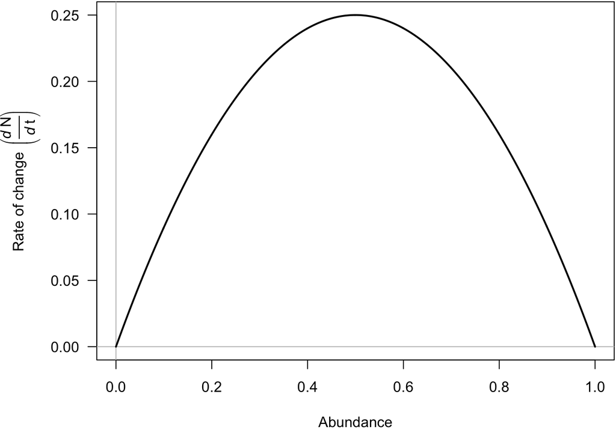

Take a moment to relate this figure back to the time series.

Now, stare at the last figure again for a minute. Could you describe a function that looks something like this? Are you thinking of something like a parabola? If so, you’re following along!

Now that you hopefully understand that the rate of change is parabolic, let’s go ahead and describe the function for the rate of change. In the first section, remember, the logistic equation had two properties that we were interested in capturing in our model: (1) when the population is small it grows and (2) when the population is large it slows. When the population is small, we can create a term that represents the growth rate of individuals. We’ll use the parameter $r$ to describe the rate of individual growth (called the intrinsic rate of growth) and multiply it by the abundance of individuals in the population:
$$\frac{dN}{dt} = rN\text{.}$$
Yes, that’s the exponential equation; the equation that describes growth without limitation. Next, we wish to represent the effect of crowding that ultimately slows population growth. We first know that the term have a negative sign because its deceasing the population growth rate. We secondly know that it will describe how a population interacts with itself, which we can include as $N \times N$. We also want a way to vary the strength of crowding, so we call it the crowding coefficient and assign it parameter $\alpha$. We now add $-\alpha NN$ to our equation above, and voilà:
$$\frac{dN}{dt} = rN -\alpha N^2\text{.}$$
This, BI271 students, is the logistic equation. Consider the anatomy of this equation for a minute. There are two terms, one with $N$ raised to the first power, the other with $N$ raised to the second power. What this means is that when $N$ is small, the first term dominates because the second term squares a small number. Consequently, when $N$ is large, the second term dominates because it squares a large number. The two terms capture how populations grow when small, and eventually stop growing when they reach a certain size.

And you can create this in R! Really, there are four steps: (1) create a set of densities across which you want to calculate the population growth rate, (2) preset some arbitrary parameter values, (3) plug the set of densities into the logistic equation to calculate the population growth rate, and (3) plot it!

```r
# (1) Create a sequence of values from 0 to 1 by 0.001
  N <- seq(from = 0, to = 1, by = 0.001)

# (2) Give parameters some arbitrary values
  r <- 1
  alpha <- 1

# (3) Plug the sequence into the logistic equation
  dNdt <- r*N - alpha*N^2

# (4) Plot the population growth rate as a function of abundance (we want the plot type to be a line)
  plot(x = N, y = dNdt, xlab = "Abundance", ylab = "Population growth rate", type = "l")
```

### 2.3.2 The solution

You might be thinking that now that you have a differential equation to describe the rate of population change, how do we relate population size to time, like we saw from the observational data of how populations change as a function of time and what we were initially Interested in describing as $N = f(t)$. To do that, you must find the solution to the differential equation, meaning that the logistic equation must be integrated. We aren’t concerned with the steps of integration, but we’ll show the result, and hopefully you’ll understand why we didn’t lead with that formula: it’s bulky and non-intuitive! But as ugly and inelegant as the solution is, it’s extremely valuable. In the solution to the logistic equation we introduce a new parameter that is the integration constant, or, in ecological terms, the initial abundance, denoted $N(0)$, for $N$ at time $0$.
$$N = \frac{rN(0)e^{rt}}{r + \alpha N(0)(e^{rt} - 1)}$$
With the logistic equation solution, we see that we can relate abundance to time. It’s important to note that if we were to differentiate (find the derivative of) the solution that we’d end up with the differential equation—they are equal to one another!

Now, let’s graphically examine the logistic equation solution. To do so, we can give $r$ and $\alpha$ values of one, the initial population something small, like 0.01, but roughly follow the same process as plotting the logistic differential equation: (1) create a time sequence over which we want to plot abundance, (2) create some arbitrary parameters, (3) plug the time sequence into the logistic equation solution, and (4) plot it! Try doing it on your own before you look at the code below.

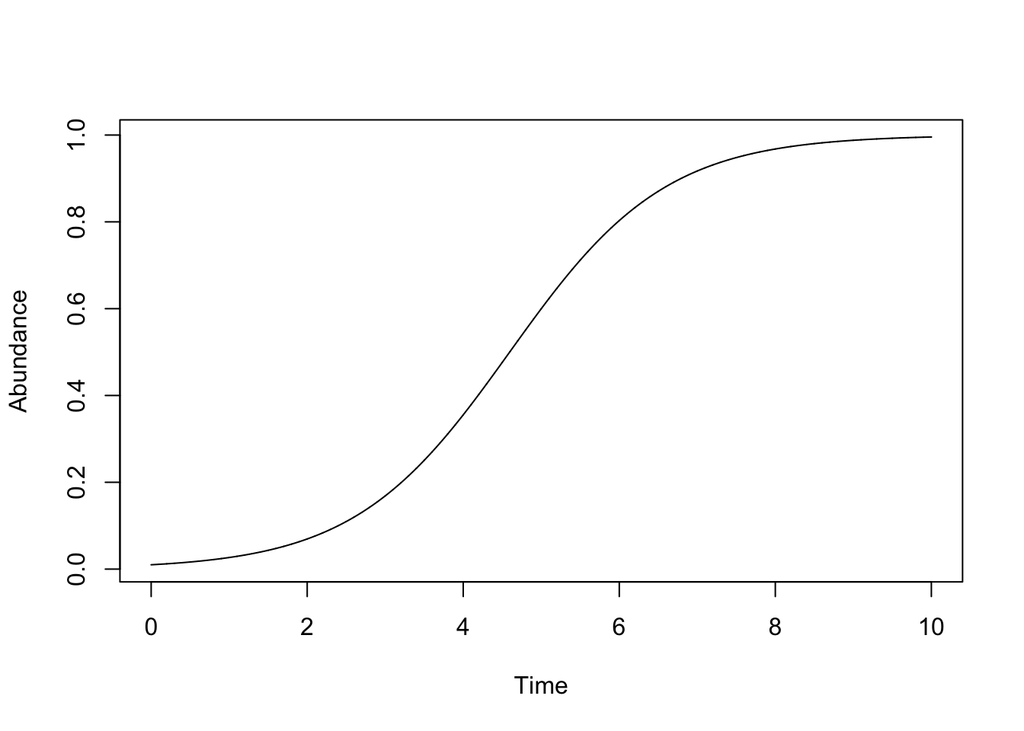

```r
# (1) Create a time sequence from 0 to, say 10, by 0.001
  t <- seq(from = 0, to = 10, by = 0.001)

# (2) Give parameters arbitrary values
  r <- 1
  alpha <- 1
  N0 <- 0.01

# (3) Plug the sequence into the logistic equation
  N <- (r*N0*exp(r*t)) / (r + alpha*N0*(exp(r*t) - 1))

# (4) Plot the population growth rate as a function of abundace (we want the plot type to be a line)
  plot(x = t, y = N, xlab = "Time", ylab = "Abundance", type = "l")
```

### 2.3.3 Models summary

You now have been bestowed with two equations related to how populations change: the logistic equation and its solution:
$$\begin{equation}
\frac{dN}{dt} = rN -\alpha N^2 \\
N = \frac{rN(0)e^{rt}}{r + \alpha N(0)(e^{rt} - 1)} \text{.}
\end{equation}$$
These are two equations expressing the same exact things in different ways. Come to be comfortable with these equations. For this lab, you’ll be growing populations in the lab, generating time series data, and estimating the intrinsic rate of growth, $r$, and crowding coefficient, $\alpha$.

# 3 Experimental protocol for the population growth experiment

## 3.1 Summary

The first half of Ecology (BI271) lecture will be concerned with how populations change. We’ll try to answer the question: How are populations regulated? One way that you’ll find out how populations are regulated is through the limitation of resources. During the first Ecology Lab, you’ll be setting up an experiment to examine the effect of limiting resources on population growth. You’ll be using a small, aquatic plant, *Lemna minor*, commonly known as duckweed ([Wikipedia](https://en.wikipedia.org/wiki/Lemna_minor)). *Lemna minor* reproduces asexually through thalli (thick, leaf-like structures), which will be the unit of measurement in this experiment. You will monitor populations daily for three weeks, and by that time *L. minor* will have completely covered the growth containers.

# 4 Experimental protocol for the population growth experiment

## 4.1 Summary

The first half of Ecology (BI271) lecture will be concerned with how populations grow. We’ll try to answer the question: How are populations regulated? One way that you’ll find out how populations are regulated is through the limitation of resources. During the first Ecology Lab, you’ll be setting up an experiment to examine the effect of limiting resources on population growth. You’ll be using a small, aquatic plant, *Lemna minor*, commonly known as duckweed ([Wikipedia](https://en.wikipedia.org/wiki/Lemna_minor)). *Lemna minor* reproduces asexually through thalli (thick, leaf-like structures), which will be the unit of measurement in this experiment. You will monitor populations daily for three weeks, and by that time *L. minor* will have completely covered the growth containers.

## 4.2 Protocol

Your lab instructor will randomly pair students. You and your partner will create two growth containers: one to grow *Lemna minor* under optimal conditions and one to grow *Lemna minor* in suboptimal conditions. The optimal treatment will be based on previous studies of the amount of pond solution and soil. The experimental treatment will deviate in the amount of soil in the cup by adding less-than-optimal amounts of soil. See your lab instructor to be assigned the random amount of soil that you will add as your experimental treatment.

First, using a permanent marker, label the cups: whether optimal or experimental, the starting date, and both of your names. Second, repeat the following for both cups:

1. Add directed amount of soil to each cup (0.8 g for the optimal treatment and *X* g for for the experimental treatment (*X* = what your instructor assigns you) by using the scoop and weigh dishes. Be sure to tare the weigh dishes before adding soil.
2. Measure 200 mL of artificial pond solution into a beaker and pour into the cup, gently.
3. Draw a line on the cup to indicate the top of the 200 mL fluid level.
4. Using a wooden stick, gently move *L. minor* plants from the stock to your cup. Your goal is to have a total of 4 thalli to start. A thallus is one ‘leaf’ that is 1.5 mm or greater. One plant can have anywhere from 1-4 thalli.
5. Count the number of thalli. For counting purposes, you will quantify the number of thallus rather than individual ‘plants.’ Do not remove any plants from the culture while counting.
6. Enter the number of thalli into the datasheet. This will be your first daily entry, and go ahead and fill out the remainder of the data for the day (e.g., time).
7. After you’ve finished counting, place lids on your cups. Take your cups and datasheet to the greenhouse. Place your cups on the tray designated for your lab section (e.g., A1, A2) and datasheet in the the portable file box in the greenhouse for your lab section.
8. Return every day for the next 3 weeks around the same time to count and record the number of thalli in each cup.

- If any of the thalli turn white or yellow, do not count them.
- To aid in counting when populations become dense, there are click counters and wooden sticks available. These sticks can be used to manipulate *L. minor*. Do not leave the stick in your cup because chemicals can leach out of the wood leading to the death of your culture.
- If you cannot access the greenhouse for some reason, please contact security if it is during weekend or evening hours to be let in. If it is M–F between 9 AM–5 PM, you can locate a faculty or staff member to give you access.
- Your instructor will discuss guidelines for counting thalli. However, it is crucial that you and your partner use consistent and accurate counting methods. To encourage this, spend time discussing and practicing your counting guidelines and technique by making use of example cultures located at the front of the lab benches.

## 4.3 Materials list

- 2 plastic cups
- 2 lids
- A permanent marker
- Scales
- Weigh dish
- Soil
- Scoop
- A carboy of artificial pond solution
- Beakers to measure
- Wooden sticks to move *Lemna minor*
- Click counters to ease counting
- Datasheet
- Pencil

# 5 Analysis

## 5.1 Enter data

The first thing that you want to do is enter your data. We ask that you enter you data in a format described by your instructor.

## 5.2 Import, examine, and summarize data

Like you did for last week’s lab, import, examine, and summarize the data. Check to make sure that the there are no irregularities in the data both by using functions that you know (e.g., `range()`) and plotting the data as single variables and abundance against time. Once the data look like they are OK, it’s time to move onto parameter estimation.

## 5.3 Parameter estimation

Now, for the most exciting part of this lab: estimating parameter values! That is, from our data, we will make statistical estimates of biologically-meaningful values from the logistic model: $r$ and $\alpha$.

We’ll be estimating parameters by using a method called *non-linear least squares* ([Wikipedia](https://en.wikipedia.org/wiki/Non-linear_least_squares)). In sum, non-linear least squares minimizes the sum of the squared distances of data from a function by changing parameter values.

If I have some toy logistic growth data (points) and the logistic equation with some parameters I made up (dotted curve), I can measure the distance between the points and the curve, square them, and get a number:

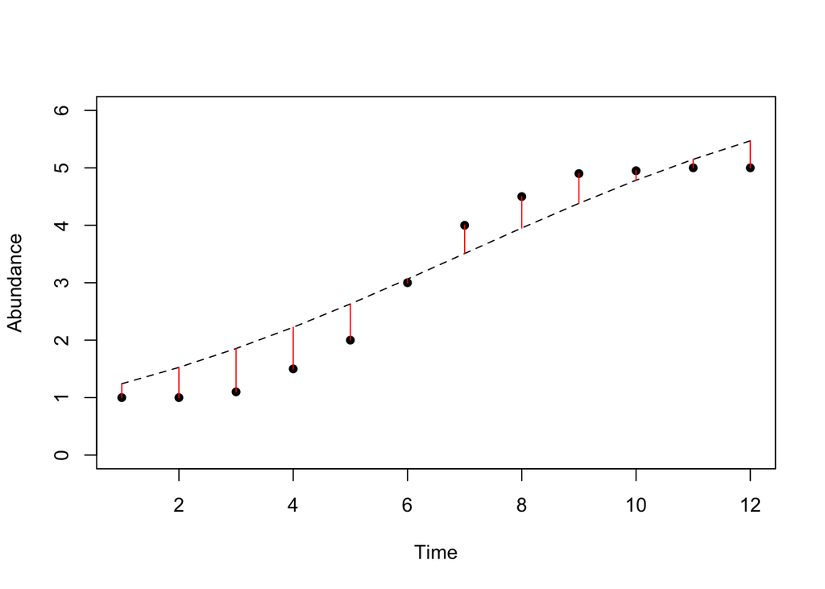

With some different parameters, with the same data will yield something that looks like this:

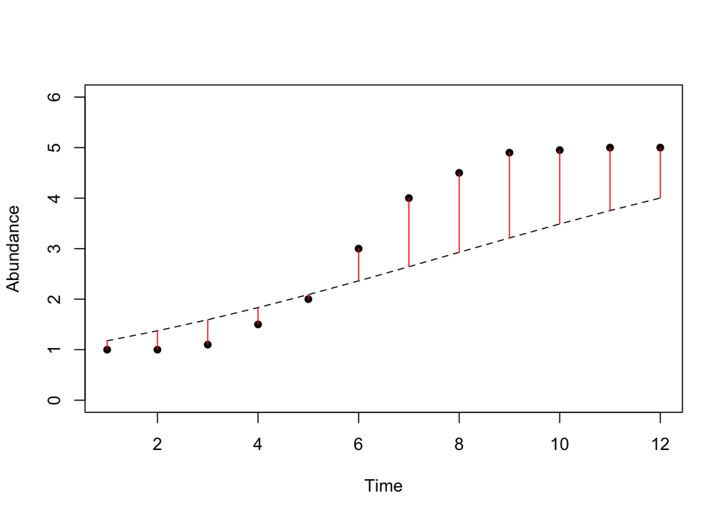

Notice how much more red (vertical difference between the curve and points) you see, meaning that the curve don’t approximate the points as well. This is essentially how non-linear least squares evaluates fit.

To visualize how different parameter values changes the shape of the curve, first plot the logistic equation from 2.3.2. Next modify $r$ and $\alpha$ in the function, and use `lines()` to plot a few different values of each parameter:

```r
# (1) Create a time sequence from 0 to, say 10, by 0.001
  t <- seq(from = 0, to = 10, by = 0.001)

# (2) Create parameters for two logistic equations
  r_1 <- 1
  r_2 <- 0.95
  alpha <- 1
  N0 <- 0.01

# (3) Plug the time sequence and parameters into the logistic equations
  Nt_1 <- (r_1*N0*exp(r_1*t)) / (r_1 + alpha*N0*(exp(r_1*t) - 1))
  Nt_2 <- (r_2*N0*exp(r_2*t)) / (r_2 + alpha*N0*(exp(r_2*t) - 1))

# (4) Plot the population growth rate as a function of abundance (we want the plot type to be a line)
  plot(x = t, y = Nt_1, xlab = "Time", ylab = "Abundance", type = "l")

# (5) Add to existing plot
  lines(x = t, y = Nt_2, col = "red")
```

Ultimately, we hope that you have a sense how both $r$ and $\alpha$ change the pattern of growth:

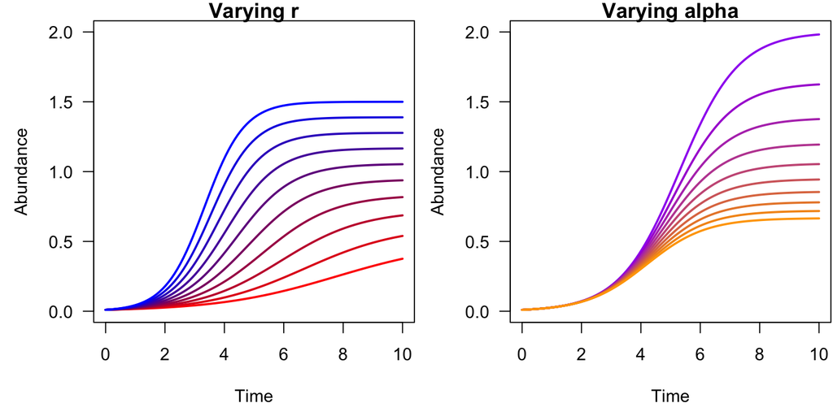

Notice the difference in the figures above when $r$ and $\alpha$ are changed. Varying $r$ changes the pattern of growth at low densities, while $\alpha$ changes the patter of growth at high densities. This is conceptually what the algorithm underlying the non-linear least squares estimate is doing while determining which combinations of $r$ and $\alpha$ returns the least squared difference of the function and data.

Now, **your turn**! The function that you will use to generate non-linear least squares estimates is: `nls()`. This function takes two arguments that will be important: (i) the `formula` of the equation and (ii) values for where you’d like the parameter search to `start`. The formula will be the solution to the logistic equation, just like you’ve been using. The format needs to be

> data ~ equation

with the data being your data (a column within your data frame). The equation will be the solution to the logistic equation with some parts known (i.e., your initial population size $N(0)$) and some parts unknown (i.e., $r$, $\alpha$). Oh, and the format for a forumla in R uses the tilde (pronounced: ’tildə): ~. Last, you need to give R some starting values for each of the parameter estimates. Remember, this algorithm can theoretically search all real numbers ($\pm \infty$), so we must supply it with some guess. Ultimately, you should produce something that looks like the following if I had data on energy (E) and wanted to estimate the values of mass (m) and the speed of light (c):

```r
nls(formula = E ~ m*c^2, start = c(m = 0.1, c = 2))
```

# 6 Report

This will be the second of 4 individual lab reports. Each report will be in the IMRaD format (**I**ntroduction, **M**ethods, **R**esults, and **D**iscussion), but will have different emphases. For this lab report, we wish to emphasize the introduction, methods, and results, but include a minor discussion section. We ask that you read several papers on density-dependent growth, and ultimately use 2—3 in your introduction.

## 6.1 Introduction

To some, the introduction section is the most important part of the scientific paper. The reason being that the introduction contextualizes the hypothesis within the broader scientific context and justifies experiment. Contextualizing the study requires rigorous scholarship and delicate intertwining of really complex ideas. A well-written introduction leaves a reader yearning for an experiment to patch the clearly and elegantly-described hole in our knowledge! A poorly-written introduction leaves the reader in existential crisis, asking: what’s the point?!

Obviously, writing a good introduction requires a thorough understanding of the science. Since you have been learning about population growth so far this semester, we expect you to draw upon what you’ve learned so far to craft a good introduction. This includes drawing upon your resources from lecture, the course text, and outside literature. We ask that you use and cite 2—3 relevant sources within the introduction.

## 6.2 Methods

A cornerstone in the scientific process is repeatability. If experiments aren’t repeatable, then other scientists cannot evaluate or build upon each other’s work. The methods section of a scientific paper is where scientists describe their experiment in enough detail that another scientist in their field should be able to repeat it nearly exactly.

For the methods section of your report, we ask that you describe what was done in the experiment, both in the lab and analytically. Please write in the active voice that includes a subject of the verb’s action (e.g., “We laid a transect” preferred over “A transect was laid”, or “I calculated the mean” over “The mean was calculated”). The section should be written with the amount of detail that an *Ecology* student in Fall 2019 could very closely replicate your experiment and analysis. It’d be helpful creating three subsections describing the biology of *Lemna minor* (1 or 2 paragraphs), the experiment (sufficient detail for repeatability), and analysis (1 or 2 paragraphs).

## 6.3 Results

The results section of a scientific paper is where the quantitative, ostensibly objective summary of the data is presented. It’s often a relatively short section, including summary and inferential statistics. Embedded within the text is often a few figures or tables that include the most pertinent relationships or findings within the study.

For this second report, we ask that you write a traditional results section. That is, verbally describe your main findings as succinctly and objectively as possible. Include the most important figures that communicate the main findings of the experiment. This section will likely be very short (1—2 paragraphs).

## 6.4 Discussion

Another minor section in this lab report, we ask that you write as much as you’d like (perhaps a paragraph or two) evaluating the experimental hypothesis in light of the data you collected.